# Huang-GenerativeAILayoffGeneration-2023-SSRN.pdf

Converted from PDF `Huang-GenerativeAILayoffGeneration-2023-SSRN.pdf` · 25 pages · anchors: page `#pN`, block `#pN-bK`

Page 1

∗Corresponding author (qingquan@illinois.edu). Authors contributed equally and are listed alphabetically.

### **The Layoff Generation: How Generative AI will Reshape**

### **Employment and Labor Markets**

Qiwen Huang, Yifan Shen, Yuanchi Sun, Qingquan Zhang*

**Abstract**: This research presents a new metric known as "AI Augmentation," aimed at quantifying the influence of generative AI across diverse job roles, organizations, and sectors. The analysis defies prevailing expectations of job losses due to AI, instead demonstrating a reverse correlation between AI Augmentation and layoff rates. These counterintuitive findings highlight the importance of a detailed, multifaceted examination of AI's impact on labor markets. This nuanced understanding is vital for making informed strategic decisions and developing effective policies.

**Key Words**: Generative AI, AI Augmentation, Layoff Rates, Employment, Labor Markets

#### **Introduction**

The transformative potential of large language models (LLMs) like ChatGPT on job markets is gaining significant traction in recent months. Such models, renowned for their capability to generate coherent and contextually relevant text, have swiftly found applications in various economic sectors. Fields like customer support, content creation, and select financial analysis tasks have seen rapid integration of these models (Haleem et al., 2022; OpenAI, 2022; Chang et al., 2023). These advancements echo the arguments of Arntz, Gregory, & Zierahn (2016) and Chui, Manyika, & Miremadi (2016), who posit that while Artificial Intelligence may not eradicate many occupations outright, it is poised to significantly alter the nature of most jobs. Such transformations are contingent on numerous factors, including the nature of the work, the technical feasibility for automation, and the interplay of benefits, costs, and labor dynamics.

However, with the ascent of LLMs, emergent concerns regarding job displacement have arisen. Preliminary data indicates a notable correlation between the incorporation of LLMs and a surge in layoff rates, especially in sectors characterized by routine textual, coding, translate and other repetitive tasks (Chen et al., 2021; Carlini et al., 2021; Felten, 2023; Yilmaz et al., 2023; Jiao et al, 2023; Webb, 2020).

As businesses stand to benefit from reduced operational costs and enhanced efficiency, there emerges a discernible tension between technological progression and job security for certain cohorts of workers. Addressing this transformative phase, our study introduces the "AI Augmentation Index." This tool is designed to gauge the susceptibility of individual professions, companies, and entire industries to LLM influences. It's paramount that decision-makers harness such tools to astutely navigate this evolving landscape, championing a vision where technology complements, rather than supplants, human expertise.

A prevalent assumption is that generative AI, with its potential to automate a plethora of tasks, will invariably lead to widespread job displacement, subsequently creating a 'layoff generation' (Arif et al., 2023). However, these dystopian forecasts often fail to account for the

Electronic copy available at: https://ssrn.com/abstract=4534294

Page 2

intricate dynamics at the interface of AI and labor markets. Understanding the relationship between AI and employment is not a straightforward equation, but rather a complex interplay that unfolds within a multitude of economic, social, and institutional contexts. In this paper, our primary focus centers on the substitutive role of ChatGPT in professional contexts. We assign scores to individual tasks across various jobs. While Eloundou et al. (2023) have categorized tasks, our analysis further incorporates real-world legal and ethical considerations, as well as the interplay between automation and large language models. By harnessing the ChatGPT API for extensive categorization, we ensure that our findings are readily replicable, thereby enhancing the robustness and applicability of our research.

To refine our computation of the AI Augmentation Index, we have taken a two-pronged approach in assessing companies and industries. Firstly, we leverage stock occupation data, akin to the methodology proposed by Eisfeldt et al. (2023), which essentially looks at the total workforce count within a company. Concurrently, in a novel approach, we incorporate data pertaining to the issuance of H-1B visas, highlighting a strong correlation between the number of H-1B visas granted and the employment landscape in the U.S (Mandal, Chaudhuri, & Prasad, 2020). We also consider the monthly increments and decrements of job postings on LinkedIn. The results derived from these diverse data sources not only corroborate each other but also open avenues for us to explore the interplay between these distinct occupational data sets in future research. This dual approach ensures a more holistic and robust understanding of AI's implications across various professional sectors.

In this research, we endeavor to elucidate the relationship between the AI Augmentation Index and employment patterns. Drawing on the work by Fingleton, Garretsen, and Martin (2012), as part of our regression construction, we've incorporated both event shocks and regional factors as control variables, ensuring a more nuanced understanding of the connection between AI Augmentation and layoff rates. Based on current labor market dynamics, our overarching conclusion indicates that companies and industries with higher AI Augmentation tend to exhibit lower layoff rates. However, in specific sectors, a contrasting trend emerges, where increased AI Augmentation correlates with higher layoffs. This counters the prevailing narrative suggesting a looming 'layoff generation' due to generative AI. Such a binary perspective on AI's impact might risk obscuring the intricate interplay between technology and employment, potentially hindering strategic decision-making and policy formulation. Additionally, our results indirectly affirm the perspectives of Zarifhonarvar (2023), Nah et al. (2023), and Nakamura and Zeira (2018). Given these findings, we advocate for a transition in discourse, moving from overarching concerns of massive layoffs to a more detailed examination of the multifaceted relationship between AI and the job market.

This research intends to encourage stakeholders across academia, industry, and policy-making to transition from a perspective of anxiety and uncertainty to one of informed understanding and strategic action. After all, the advent of generative AI presents not only challenges but also opportunities - opportunities for job creation, industry evolution, workforce upskilling, and overall socio-economic development, which must be leveraged in the era of AI-driven transformations.

Electronic copy available at: https://ssrn.com/abstract=4534294

Page 3

#### **Literature review**

The pervasive influence of Large Language Models (LLMs) on the labor market is profound and unpredictable, particularly concerning labor demand. (Korinek and Stiglitz, 2018; Bessen, 2018; Acemoglu et al., 2020; Benzell et al., 2021) With the introduction of ChatGPT, AI's transformative potential is reshaping modern industries, innovatively blending technologies like machine learning, natural language processing, and robotics. This has facilitated AI's seamless assimilation into numerous sectors, setting the stage for a new economic landscape.(Aghion et al., 2018; ) This literature review seeks to offer a thorough exploration of the AI exposure across S&P 500 companies, shedding light on AI's multifaceted impact, and unearthing potential avenues for further investigation.

(Brougham and Haar, 2018) delve into employees' conceptualizations of AI's role within professional ecosystems. They elucidate that discerning tasks most prone to automation may unveil avenues to recalibrate employee engagement and optimize digital labor platforms. Different from automatic technologies, Generative artificial intelligence (AI) is able to perform cognitive functions and engage in creative endeavors. The application of generative AI would dramatically reshape the fabric of work as we comprehend it. Firms are able to deconstruct occupations into task bundles and assigned different tasks to narrow AI and generative AI based on the existing algorithms (Castillo, 2023). Such insights underscore the imperative to quantitatively assess AI's penetration, paving the way for its more nuanced assimilation in the workplace.

Intricately extending this concept, our research bifurcates AI Augmentation into two distinct facets: augmentation and replacement. This dichotomy allows us to offer a more granular perspective on the varying impacts of AI across different occupations. The rationale for this bifurcation stems from the understanding that the effects of AI on jobs are not homogeneous. Instead, these effects are contingent on whether AI technologies augment human efforts by assuming certain tasks or supplant humans entirely in specific job roles. The concepts of augmentation and replacement form a critical dichotomy in the discussion of AI's influence on employment. Augmentation represents a scenario in which AI technologies serve as an enabler, enhancing the efficiency of individuals in performing specific tasks. Conversely, replacement represents a scenario where AI technologies assume the entire role of a given position, effectively eliminating the need for human involvement. This latter scenario can be viewed as an extreme manifestation of augmentation. The transition from augmentation to replacement is not seamless, however, and is subject to three primary constraints. By distinguishing between augmentation and replacement, we offer a more comprehensive framework for analyzing AI's labor market impact.

While distinguishing between augmentation and replacement, we consider automation to be the key component in the framework. Our research contributes a novel angle to the discourse on whether automation complements or replaces labor, a question that has been considered but not fully answered in the existing literature. (Lawrence et al., 2017) postulate that automation may lead to job losses, and the extent of these losses depends on whether automation supplements or replaces labor. Similarly, (Eloundou et al., 2023) present two key concepts to explain the labor market impacts of Large Language Models (LLMs). They discuss the skill-biased concept of technological change, which posits that technological advances favor more skilled and educated workers, and the automated task model, which

Electronic copy available at: https://ssrn.com/abstract=4534294

Page 4

suggests that generative AI is used to automate specific tasks rather than entire jobs. (Noy and Zhang, 2023) provides an answer to the question of how generative AI systems affect employee productivity in the context of intermediate-level professional tasks, in particular the aspect of whether they replace the employee's efforts or complement the employee's skills.

Taking into account ethical and legal considerations, as well as the current limitations of generative AI technologies, we have incorporated these factors into our framework when formulating the rubric for calculating the AI Augmentation index. For instance, legal ambiguities surrounding liability may restrict the application of generative AI tools such as ChatGPT in sensitive fields like healthcare (Dave, Athaluri, & Singh, 2023). (Jiang et al., 2021) indicate that amidst the rapid development and integration of AI in the medical domain, several emerging challenges have surfaced, especially the lack of standardized processes, ethical and legal concerns, and other impediments . Furthermore, technological deficiencies in integrating large language models with automation could inhibit the replacement of certain occupations (Ahmad et al., 2023). This limitation is compounded by the current stage of large language model technology development. In handling intricate problems, large language models often display a 'hallucination effect', whereby they fabricate terms or facts as needed (Shen et al., 2023). This highlights an existing technical shortcoming in the evolution of large language models.The importance of differentiating between full job replacement and augmentation of human capabilities by AI is underscored by these complexities, and our paper makes a significant contribution by providing a nuanced analysis of these distinct scenarios.

(Eisfeldt et al., 2023) illuminates the influence of Generative AI on firm values through a unique firm-level exposure metric. This marks an evolution from prior research that primarily considered occupational exposure. The authors' innovative approach, which maps the aggregate of task-level exposure metrics to the occupations in the O*NET database (O*NET, 2023), and then to publicly traded companies, provides a new lens through which to explore the economic repercussions of AI advancements. This method demonstrated that firms with higher exposure to Generative AI technologies experienced higher excess returns following the release of ChatGPT.

We consider the analysis of the labor market in the context of evaluating the economic impacts of generative AI is of paramount importance, as it directly influences productivity, income distribution, consumer demand, and structural shifts in the economy. Generative AI technologies can potentially automate routine tasks and amplify efficiency, thereby impacting productivity and economic growth rates. (Agrawal et al., 2019) against drawing broad conclusions from factory automation studies, emphasizing the need for further research into the effects of AI on the labor market . Therefore, a detailed labor market analysis can provide critical insights for informing strategies to maximize the benefits of AI.

Building upon this groundwork, our research brings an original perspective to the field by offering a more comprehensive, nuanced analysis that leverages diverse datasets, including H-1B visa records, job postings trends, and data from Revelio Labs. Our method disrupts the pervasive belief that AI will invariably cause widespread unemployment and instead presents a deeper understanding of the intricate relationship between technology innovation and labor market dynamics. We extend our analysis to all 25 industries in the S&P 500 Index, correlating AI Augmentation scores with layoff trends for each industry's

Electronic copy available at: https://ssrn.com/abstract=4534294

Page 5

companies. This unique and meticulous approach uncovers nuanced patterns, substantiating the hypothesis that Generative AI impacts labor markets in multifaceted and surprising ways. Notably, our work underscores that the effects of Generative AI on employment are far from uniform, varying significantly across different industries. The groundbreaking insights we provide will significantly contribute to the ongoing discourse on the socio-economic impact of AI.

While (Eloundou et al., 2023) acknowledges that generative AI is changing the labor market by providing new job opportunities while AI advancement also displacing some occupation, they caution that it is too early to definitively predict the potential impact of LLMs on the U.S. labor market.

In contrast to this cautionary stance, our research provides concrete evidence of generative AI's impact on the labor market in the short term. It even suggests that these effects might be predictable in the long term. We demonstrate that some industries are already witnessing a rise in unemployment rates while others are experiencing the contrary. This aligns with Eloundou's premise but significantly extends it by providing tangible, real-world data that illustrates the nuanced and differential impacts of generative AI across industries. Our findings, therefore, are not just complementary to Eloundou's theoretical framework but also serve as a valuable empirical extension of it. We have uncovered industry-specific patterns that further elucidate the relationship between AI Augmentation and employment trends, thereby contributing robust evidence to the ongoing discourse on the socio-economic implications of AI technology.

Electronic copy available at: https://ssrn.com/abstract=4534294

Page 6

(Frank, et al., 2019) noted the uncertain impact of technology on labor makes it challenging to construct resilient labor markets. Technological changes can cause shifts in specific skill demands, leading to broader labor trends, such as the redefinition of occupational skills, employment redistribution, and worker migration. Similarly, according to findings by (Frey and Osbone, 2016), as technology advances, low-skill workers will need to transition to tasks impervious to computerization, specifically those requiring creative and social intelligence. Thus, for workers to maintain competitiveness, the acquisition and enhancement of these skills are imperative.

In essence, our work exposes the nuanced and industry-specific impacts on employment. It unravels the complex labor market dynamics in these sectors, elucidates the multifaceted impacts of AI, and offers a more granulated understanding of the socio-economic ramifications of AI adoption across different industries.

As discussed above, our research presents compelling evidence that the impacts of generative AI on labor markets are primarily short-term. This observation aligns with (Zarifhonarvar, 2023) theory , which posits a short-term disruption followed by potential long-term equilibrium. The short-term effects we have documented lend empirical weight to this theory while paving the way for a more nuanced understanding of the long-term implications of AI on job markets. This short-term disruption manifests in the form of a 'skills mismatch.' As generative AI technologies like ChatGPT replace certain job roles, there is a disjunction between the skills demanded by the new, AI-integrated job market and the capabilities of displaced employees. This mismatch can result in prolonged unemployment for those unable to re-skill or transition to new roles. Although opportunities for re-skilling may mitigate the adverse effects of AI on the job market, the reality of time constraints and the fast pace of AI adoption can lead to temporary mismatches between worker skills and employer needs. This, in turn, may result in unemployment or underemployment in specific sectors.

Our research, therefore, substantiates above theoretical predictions and contributes novel, empirical insights into the differential impacts of AI Augmentation across various industries. This enriches our understanding of the short-term disruptions and long-term implications of AI on labor markets, while (Bessen, 2019) also posits that technologies enhancing productivity may augment employment within certain sectors. Utilizing data spanning two centuries from the manufacturing industries, the Bessen demonstrates a stimulatory effect of automation on employment, which increased productivity and job proliferation. Bessen

Electronic copy available at: https://ssrn.com/abstract=4534294

Page 7

speculates that contemporary technology could precipitate contraction in some industries while fostering growth in others. Consequently, while automation may not directly engender mass unemployment, it could necessitate disruptive labor transitions towards burgeoning industries, thereby demanding the acquisition of novel skills and occupations.

We assume an optimistic outlook on the long-term impact of generative AI on the job market, a perspective substantiated by the following works. (Nakamura and Zeira, 2018) constructed a task-based theoretical model, and the results are relatively optimistic. By analyzing the mathematical modeling and analysis of this model, the model suggests that automation does not necessarily lead to unemployment and that unemployment due to automation is expected to decline over time. (Lim and Lee, 2022) provides a unique insight into how technological advancement affects employment, discussing the relationship between innovation and employment, with a focus on the impact of product and process innovation on job creation . For the purposes of this paper, process innovation refers to the introduction of new or improved methods of production, such as changes in the way goods or services are produced, delivered, or distributed. Product innovation, on the other hand, refers to the introduction of new or improved goods or services, such as new or improved products, services, or processes. Lim and Lee conducted a firm-level empirical analysis using long-term data on Korean firms and industries, confirming that product innovations have a positive employment impact, while the impact of process innovations tends to be varied or negligible. Product innovation has a positive impact on employment growth in the long run, and even though product innovation tends to have a negative impact in the short run, this negative impact will be offset by positive spillovers in the long run. In the long run, however, generative AI has positive externalities, such as increased productivity and innovation efficiency, which can lead to companies developing and improving products at a faster rate, thus creating more jobs, and increasing employment.

(Autor, 2015) contends that while automation has indeed been developed to substitute labor, it concurrently serves as a complement to labor, augmenting output and consequently catalyzing an increased demand for labor. This nuanced perspective challenges prevalent narratives that overstate the displacement of human labor by machines neglecting the symbiotic relationship between automation and labor that bolsters productivity elevates earnings, and fuels labor demand. In considering the advent of artificial intelligence and robotics, the author suggests that the interplay between machine and human comparative advantage facilitates the substitution of workers in routine tasks whilst simultaneously amplifying the human advantage in problem-solving, adaptability, and creativity.

(Lawrence, Roberts and King, 2017) also share the same view with (Lim and Lee,2022) , which indicated that AI automation has a positive for the job market because it has a substantial positive spillover effect, which in the long run, AI automation has a positive impact on the job market. In the long run, AI automation may change the way work is done and productivity rather than eliminating jobs. Lawrence argues that automation may lead to job losses in the short term, but in the long run, it may also create new jobs. Also, the paper suggests that if demand keeps pace with the increase in output, employment levels may remain constant or even grow. But it will take businesses as well as society to decide how automation will reshape the economy as well as the industrial landscape.

Electronic copy available at: https://ssrn.com/abstract=4534294

Page 8

**Data and Methodology** The Steps Involved in Calculating AI Augmentation

In this study, we propose a systematic approach to quantify an organization's Augmentation to artificial intelligence (AI), comprised of four methodical steps. The process is illustrated in Figure 1. We base our computation approach on the groundwork provided by (Eisfeldt et al., 2023), enhancing it with our novel contributions.

Notably, the 'H-1B' and 'post and remove' measures we employ are based on incremental occupational data, capturing changes in the job market. In parallel, we also reference findings from Revelio Labs, which uses a different approach. Revelio Labs capitalizes on stock occupational data, which represents the accumulated job positions within a company, to calculate firm Augmentation. In this study, we employ a cross-utilization strategy, integrating the results from our incremental data with Revelio Lab's stock occupations data to provide a comprehensive perspective on firm-level AI Augmentation.

Rubric of Replacement

Drawing upon the methodologies of (Brynjolfsson, 2018; Felten et al., 2018; Webb, 2020), we have likewise developed a standardized measure for the tasks associated with each occupation. We introduce a comprehensive task-based classification rubric that evaluates the potential of AI to replace tasks across various occupations. It offers a nuanced assessment of the degree of AI-replacement potential, considering factors beyond mere technical feasibility, and encompassing legal, ethical, and social dimensions. The rubric is divided into three categories: No Augmentation (A0), Weak Augmentation (A1), and Strong Augmentation (A2), with detailed criteria outlined for each category. A detailed representation of the rubric can be found in Table 1.

The "No Augmentation" category (A0) includes tasks that are currently not suitable for automation or AI augmentation, often due to the high level of judgement, interaction, and adaptability required. These tasks often deal with complex human interactions, unpredictable situations, or involve important decision-making that can significantly affect human lives or livelihoods. Moreover, they may also involve activities that legally require human

Electronic copy available at: https://ssrn.com/abstract=4534294

Page 9

involvement.

The "Weak Augmentation " category (A1) includes tasks that can be partially augmented by technology. These tasks are typically characterized by a blend of structured, automatable tasks and unstructured tasks that necessitate human judgment or interaction. In many of these tasks, technology can assist or augment human performance, but not entirely replace it. These tasks can also require regular oversight, adjustment, or input from a human.

Lastly, the "Strong Augmentation" category (A2) includes tasks that can be fully augmented by technology. The tasks involved are typically highly structured and repeatable, without a necessity for human judgement, creativity, or complex human interaction. Automation can perform these tasks consistently and at scale, and they do not involve making decisions that might significantly impact human lives or livelihoods. Importantly, these tasks do not legally require human involvement.

This rubric builds upon and innovates beyond the foundation laid by Eloundou et al. (2023), offering several notable advantages. First, it integrates ethical, legal, and social considerations, making it more comprehensive and holistic. Second, by discerning between tasks that can be fully, partially, or not at all replaced by AI, it provides a more fine-grained understanding of AI's potential impact on the workforce. Thus, this approach equips us with a robust and nuanced tool for forecasting the transformative effects of AI on various occupations.

**AI Augmentation in S&P 500** Occupation level AI Augmentation

By applying the procedural framework described earlier, we have compiled AI Augmentation indices for 923 unique occupations. To portray the broad range of AI Augmentation inherent in these positions, we have opted to spotlight the occupations at both ends of the spectrum – the top 10 and bottom 10 – ranked by their respective AI Augmentation. These are presented for ease of reference in Table 2.

Firm level AI Augmentation

Our calculations of AI Augmentation for both stock and incremental occupations have been sorted, and the top ten companies with the highest AI Augmentation are listed in Table 3 and Table 4, respectively. These tables provide a comprehensive view of the industries most affected by AI Augmentation, helping stakeholders to better understand the current AI trends and potential future shifts in the job market.

Industry level AI Augmentation

Drawing from the cumulative AI Augmentation indices developed using H-1B visa and LinkedIn 'post and remove' data, indicative of an incremental perspective, as well as the

Electronic copy available at: https://ssrn.com/abstract=4534294

Page 10

Revelio Labs dataset, representing a stock viewpoint, we undertook a thorough examination of all constituent corporations within the S&P 500. For the purpose of sectoral stratification, we employed the Global Industry Classification Standard (GICS), thereby facilitating a segmented analysis. The subsequent computation of AI Augmentation at an industry level was realized by determining the mean AI Augmentation of firms within each respective industry, with the outcomes visually represented in Figure 4. Similarly, we have also ranked each industry within the S&P 500 index based on both stock and incremental data. The respective tables are presented as Table 5 and Table 6.

#### **The Relationship between Generative AI and Employment**

Upon establishing the AI Augmentation index for each company, we further supplemented this analysis with information on the layoff rates and total numbers of layoffs for each corporation in the S&P 500, leveraging data procured from Revelio Labs spanning the years 2019 to 2023. This encompassing time frame allows us to inspect potential temporal trends and the influence of external events, such as the advent of COVID-19, on AI Augmentation and subsequent layoff patterns. The relationship between unemployment rates and AI Augmentation is illustrated in Figure 5. In addition, to offer a more comprehensive exploration of the dynamics between AI Augmentation and unemployment rates, we formulated a regression model. This approach allows us to delve deeper into the intricate correlations between these two elements.

**equation / math rendering (image)**

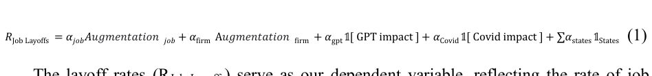

NOTE: contains mathematical notation; text above is the PDF text layer and symbols may be mis-extracted. Image shows the original.

The layoff rates (RJob Layoffs) serve as our dependent variable, reflecting the rate of job terminations for the companie’s occupations under study. The variable Augmentationjob measures the generative AI Augmentation at the occupational level within these firms, while Augmentationfirm provides a comprehensive assessment of the firm's total AI Augmentation. These two variables are the focal point of our investigation, expected to shed light on how susceptibility to AI influences labor dynamics within these organizations.

Accounting for temporal factors, we include GPT impact and Covid impact as time dummy variables in our model. GPT impact is constructed to capture the potential effect of generative AI models, especially since the advent of GPT-3 in June 2020 and GPT-4 in 2022. Covid impact, on the other hand, seeks to capture the labor market effects associated with the COVID-19 pandemic, an extraneous variable that significantly altered the business landscape during our period of study.

Lastly, to control for regional influences, we introduce the States variable, which segments the companies into four geographic categories based on their primary hiring locations. The categories include the East Coast, Midwest, West Coast, and Other regions. This variable enables us to account for any potential regional disparities in the labor market dynamics or technology adoption patterns.

The results of this multivariate regression analysis are provided in Table 7. This comprehensive representation allows us to discern the degree of influence each variable has on the dependent variable, the layoff rates. By interpreting these results, we aim to enhance our understanding of the intricate relationship between a firm's AI Augmentation and its employee layoff rates, in the context of major U.S. corporations within the S&P 500.

Electronic copy available at: https://ssrn.com/abstract=4534294

Page 11

In addition to our sector-based analysis, we further present a company-specific exploration. We have identified the top 20 companies with the highest layoff rates and total number of layoffs in 2023, contrasting these figures with their AI Augmentation levels from 2022. These relationships are graphically depicted in Figures 7 and 8. Similarly, we have determined the top 20 companies with the highest recruitment rates and total number of hires, presenting these alongside their 2022 AI Augmentation levels in Figures 9 and 10.

Both occupation and firm-level AI Augmentation are inversely correlated with layoff rates, suggesting that higher AI Augmentation may be associated with lower layoffs, potentially due to effective adaptation to market shifts. The introduction of GPT technologies appears to correlate with decreased layoffs, possibly reflecting AI-induced efficiency gains. In contrast, the onset of the COVID-19 pandemic marked a rise in layoffs, likely due to wide-scale economic disruptions. Regional differences also emerge, with the East Coast, Midwest, and West Coast showing positive associations with layoff rates, possibly indicating varying regional economic conditions or industry compositions.

Moreover, it's worth noting that these results are reflective of the current state of affairs, and the full impact of generative AI on employment may not yet have manifested. The displacement effect of generative AI may still be in its infancy, and the long-term consequences remain to be seen. The transformation brought by generative AI is profound, necessitating continuous observation and analysis as it evolves over time.

#### **Conclusion**

Our research reveals that the discourse surrounding the advent of AI and its impact on labor markets is more complex than widely perceived. While the introduction of generative AI into various sectors does present a potential for job displacement, our study demonstrates an inverse relationship between AI Augmentation and layoff rates. This finding challenges the common notion of an impending "layoff generation" due to AI. The complexities inherent in the relationship between AI and employment necessitate a shift in narrative and a more nuanced approach to strategic decision-making and policy formulation.

Electronic copy available at: https://ssrn.com/abstract=4534294

Page 12

**References** Acemoglu, D., Autor, D., Hazell, J., and Restrepo, P. (2020). Ai and jobs: Evidence from

online vacancies.Technical report, National Bureau of Economic Research.

Ahmad, A., Waseem, M., Liang, P., Fahmideh, M., Aktar, M. S., & Mikkonen, T. (2023, June).

Towards human-bot collaborative software architecting with ChatGPT. In Proceedings of the 27th International Conference on Evaluation and Assessment in Software Engineering (pp. 279-285).

Agrawal, A., Gans, J. S., & Goldfarb, A. (2019). Artificial Intelligence: The Ambiguous

Labor Market Impact of Automating Prediction. Journal of Economic Perspectives, 33(2), 31-50.

Arif, T. B., Munaf, U., & Ul-Haque, I. (2023). The future of medical education and research:

Is ChatGPT a blessing or blight in disguise?. Medical education online, 28(1), 2181052.

Arntz, M., Gregory, T., & Zierahn, U. (2016). The Risk of Automation for Jobs in OECD

Countries: A Comparative Analysis. OECD Social, Employment and Migration Working Papers, No. 189, OECD Publishing, Paris.

Autor, David H. 2015. "Why Are There Still So Many Jobs? The History and Future of

Workplace Automation." Journal of Economic Perspectives, 29 (3): 3-30.

Benzell, S. G., Kotlikoff, L. J., LaGarda, G., and Ye, V. Y. (2021). Simulating endogenous

global automation.Working Paper 29220, National Bureau of Economic Research.

Bessen, J. (2018). Artificial intelligence and jobs: The role of demand. In The economics of

artificial intelligence: an agenda, pages 291–307. University of Chicago Press.

Bessen, J.(2019). Automation and jobs: when technology boosts employment. Economic

Policy, 34(100), 589–626.

Brougham, D., & Haar, J. (2018). Smart Technology, Artificial Intelligence, Robotics, and

Algorithms (STARA): Employees' perceptions of our future workplace. Journal of Management & Organization, 24(2), 239-257.

Brynjolfsson, E., Mitchell, T., and Rock, D. (2018). What can machines learn, and what does

it mean for occupations and the economy? AEA Papers and Proceedings, 108:43–47.

Carlini, N., Tramer, F., Wallace, E., Jagielski, M., Herbert-Voss, A., Lee, K., ... & Raffel, C.

(2021). Extracting training data from large language models. In 30th USENIX Security Symposium (USENIX Security 21) (pp. 2633-2650).

Electronic copy available at: https://ssrn.com/abstract=4534294

Page 13

Chang, Y., Wang, X., Wang, J., Wu, Y., Yang, L., Zhu, K., ... & Xie, X. (2023). A Survey on

Evaluation of Large Language Models. arXiv preprint arXiv:2307.03109v6.

Chen, M., Tworek, J., Jun, H., Yuan, Q., de Oliveira Pinto, H. P., Kaplan, J., ... & Zaremba, W.

(2021). Evaluating Large Language Models Trained on Code. arXiv preprint arXiv:2107.03374v2.

Chui, M., Manyika, J., & Miremadi, M. (2016). Where machines could replace humans-and

where they can’t (yet).

Dave, T., Athaluri, S. A., & Singh, S. (2023). ChatGPT in medicine: an overview of its

applications, advantages, limitations, future prospects, and ethical considerations. Frontiers in Artificial Intelligence, 6, 1169595.

Eisfeldt, Andrea L. and Schubert, Gregor and Zhang, Miao Ben, Generative Ai and Firm

Values (May 2023). NBER Working Paper No. w31222.

Eloundou, Tyna, Manning, Sam, Mishkin, Pamela, & Rock, Daniel (2023). GPTs are GPTs:

An early look at the labor market impact potential of large language models.

Felten, E., Raj, M., & Seamans, R. (2023). How will Language Modelers like ChatGPT

Affect Occupations and Industries?. arXiv preprint arXiv:2303.01157.

Felten, E. W., Raj, M., and Seamans, R. (2018). A method to link advances in artificial

intelligence to occupational abilities. AEA Papers and Proceedings, 108:54–57.

Fingleton, B., Garretsen, H., & Martin, R. (2012). Recessionary shocks and regional

employment: evidence on the resilience of UK regions. Journal of regional science, 52(1), 109-133.

Frank, M. R., Autor, D. H., Bessen, J. E., Brynjolfsson, E., Cebrian, M., Deming, D. J., ... &

Rahwan, I. (2019). Toward understanding the impact of artificial intelligence on labor. Proceedings of the National Academy of Sciences.

Frey, Carl B., & Osborne, Michael A. (2017). The future of employment: How susceptible are

jobs to computerisation? Technological Forecasting and Social Change, 114, 254-280.

Haleem, A., Javaid, M., & Singh, R. P. (2022). An era of ChatGPT as a significant futuristic

support tool: A study on features, abilities, and challenges. Bench Council Transactions on Benchmarks, Standards, and Evaluations, 2(4), 100089.

Korinek, A. and Stiglitz, J. E. (2018). Artificial intelligence and its implications for income

distributionand unemployment. In The economics of artificial intelligence: An agenda, pages 349–390. University of Chicago Press.

Electronic copy available at: https://ssrn.com/abstract=4534294

Page 14

Jiao, W., Wang, W., Huang, J. T., Wang, X., & Tu, Z. (2023). Is ChatGPT a good translator? A

preliminary study. arXiv preprint arXiv:2301.08745.

Jiang, L., Wu, Z., Xu, X., Zhan, Y., Jin, X., Wang, L., & Qiu, Y. (Year). Opportunities and

challenges of artificial intelligence in the medical field: current application, emerging problems, and problem-solving strategies. Journal of International Medical Research.

Lawrence, M., Roberts, C., & King, L. (2017). IPPR Commission on Economic Justice

Managing Automation Employment, inequality, and ethics in the digital age. IPPR.

Lim, J, & Lee, K (2022). Does innovation by firms still create jobs even after the business

stealing effect at the sector level? Journal of Economic Policy Reform.

Mandal, B., Chaudhuri, S., & Prasad, A. S. (2020). Unemployment of Unskilled Labor due to

COVID-19 led Restriction on Migration and Trade.

Nah, Fiona F.-H., Zheng, Ruilin, Cai, Jingyuan, Siau, Keng, & Chen, Langtao (2023).

Generative AI and ChatGPT: Applications, challenges, and AI-human collaboration. Journal of Information Technology Case and Application Research.

Nakamura, Hideki and Zeira, Joseph (2018). Automation and Unemployment: Help Is on the

Way. Available at SSRN: https://ssrn.com/abstract=3202622.

Noy, Shakked, & Zhang, Whitney (2023). Experimental Evidence on the Productivity Effects

of Generative Artificial Intelligence.

O*NET (2023). O*net 27.2 database.

OpenAI (2022). Introducing chatgpt.

Ponce Del Castillo, A. (2023). Generative AI, generating precariousness for workers?. AI &

Soc. https://doi.org/10.1007/s00146-023-01719-9.

Shen, Y., Heacock, L., Elias, J., Hentel, K. D., Reig, B., Shih, G., & Moy, L. (2023).

ChatGPT and other large language models are double-edged swords. Radiology, 307(2), e230163.

Tolan, S., Pesole, A., Martínez-Plumed, F., Fernández-Macías, E., Hernández-Orallo, J., and

Gómez, E. (2021). Measuring the occupational impact of ai: tasks, cognitive abilities and ai benchmarks. Journal of Artificial Intelligence Research, 71:191–236.

Webb, M. (2020). The impact of artificial intelligence on the labor market. Working paper,

Stanford University.

Electronic copy available at: https://ssrn.com/abstract=4534294

Page 15

Yilmaz, R., & Karaoglan Yilmaz, F. G. (2023). Augmented intelligence in programming

learning: Examining student views on the use of ChatGPT for programming learning. Computers in Human Behavior: Artificial Humans, 1(2), 100005.

Zarifhonarvar, Ali (2023). Economics of ChatGPT: A Labor Market View on the

Occupational Impact of Artificial Intelligence

Electronic copy available at: https://ssrn.com/abstract=4534294

Page 16

**Appendix** Figure 1: The Steps Involved in Calculating AI Augmentation

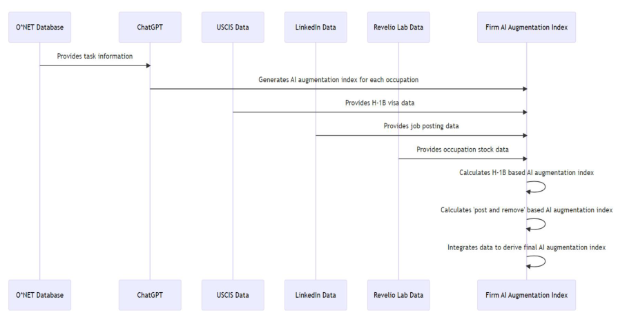

NOTE: figure/graphic rendered as an image from the PDF; its content is not machine-readable text. Caption (if any) follows as the next block.

Electronic copy available at: https://ssrn.com/abstract=4534294

Page 17

Table 1: Replacement Rubric **Category Criteria** A0 - No Augmentation 1. The task requires high degree of human judgment or decision-making based on complex and

| Category | Criteria |
| --- | --- |
| A0 -NoAugmentation | 1 The task requires high degree of human judgment or decision-making based on complex and . |
|  | non-standardized criteria which the current technology cannot reliably support , . |
|  | 2 Thetaskrequiresasignificantdegreeofhumaninteractionorpersonalizedservicewherea"human . |
|  | touch"iscritical . |
|  | 3 The task involves physical manipulation or navigation in a complex unpredictable environment . , |
|  | thattechnologycannotadapttooroperateineffectively . |
|  | 4 The task requires a deep understanding of and ability to navigate complex human social and . , , |
|  | culturalnormsthatarebeyondthescopeofcurrenttechnology . |
|  | 5 The task involves dealing with unexpected situations or emergencies that require human . |
|  | adaptabilityandcriticalthinkingskills . |
|  | 6 Thetaskinvolvesdecisionsoractivitiesthatsignificantlyimpacthumanlives andwhichtherefore . , |
|  | carryahighlevelofresponsibilityandaccountability . |
|  | 7 Legal restrictions or ethical considerations prevent the application of technology to assist or . |
|  | augmentthetask . |
| A1 -WeakAugmentation | 1 The task involves a combination of structured elements that can besupported by technology and . |
|  | unstructuredelementsthatrequirehumanjudgment . |
|  | 2 Thetaskoccursinavariablecontextorenvironmentthatrequireshumanadaptability eventhough . , |
|  | certainaspectsofthetaskcanbeassistedbytechnology . |
|  | 3 Technologycanenhancehumanperformanceinthetask butcannotfullyreplacethehumandueto . , |
|  | theneedforhumanjudgment creativity orpersonalizedservice , , . |
|  | 4 The task involves processing complex information where technology can assist in preliminary . |
|  | analysis but final interpretation or decision-making requires human expertise , . |
|  | 5 Thetaskrequiresphysicalinteractioninapartiallystructuredenvironment wheretechnologycan . , |
|  | assistbutnotfullyreplacehumaninvolvement . |
|  | 6 The task requires regular human oversight adjustment or input to ensure correct performance . , , , |
|  | eventhoughcertainaspectscanbeautomated . |
|  | 7 Legalorethicalconsiderationsallowonlyforpartialtechnologicalaugmentationofthetask . . |
| A2 -StrongAugmentation | 1 The task involves highly structured repeatable activities that can be significantly enhanced by . , |
|  | technology . |
|  | 2 Thetaskcanbecompletedthroughdigitalorvirtualmeans orinvolvesphysicalactivityinahighly . , |
|  | controlledandpredictableenvironment makingitconducivetotechnologicalaugmentation , . |
|  | 3 Thetaskinvolvesprocessingoranalyzingstructureddatawhereautomationtools includingLLM . , , |
|  | canperformaswellorbetterthanhumans . |
|  | 4 Technologycanperformthetaskconsistentlyandatscale reducingtheneedforhumanoversight . , |
|  | orintervention . |
|  | 5 Thetaskdoesnotinvolvecomplexhumaninteractionorrequireunderstandingofnuancedsocialor . |
|  | culturalnorms . |
|  | 6 The task does not involve decisions that would significantly impact human lives or livelihoods . , |
|  | makingitsaferandmoreethicallyacceptablefortechnologytotakeonalargerrole . |
|  | 7 There are no legal restrictions or ethical considerations preventing the use of technology to . |
|  | augmentthetasktoasignificantdegree . |

NOTE: table converted from PDF layout to HTML text; cell boundaries are reconstructed. See PDF if exact alignment matters.

Electronic copy available at: https://ssrn.com/abstract=4534294

Page 18

Table 2: Partial Occupational AI Augmentation

[output not shown]

NOTE: table converted from PDF layout to HTML text; cell boundaries are reconstructed. See PDF if exact alignment matters.

Electronic copy available at: https://ssrn.com/abstract=4534294

Page 19

Figure 2: Top 10 Companies by AI Augmentation Among the Top 100 Market Cap Firms in the S&P 500, 2023

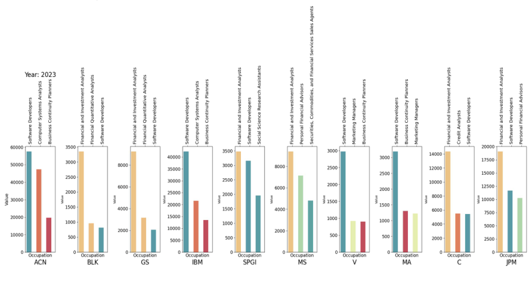

NOTE: figure/graphic rendered as an image from the PDF; its content is not machine-readable text. Caption (if any) follows as the next block.

Figure 3: Bottom 10 Companies by AI Augmentation Among the Top 100 Market Capitalization Firms in the S&P 500, 2023

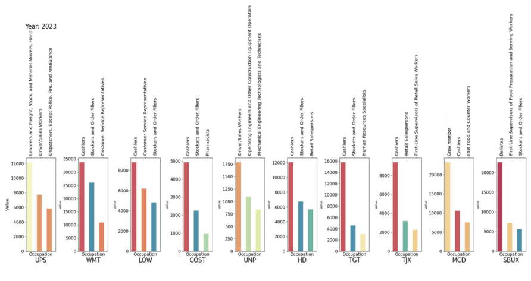

NOTE: figure/graphic rendered as an image from the PDF; its content is not machine-readable text. Caption (if any) follows as the next block.

Electronic copy available at: https://ssrn.com/abstract=4534294

Page 20

Table 3: Top 10 Companies with the Highest AI Augmentation Based on Stock Data

| ticker | Industry | 2019 | 2020 | 2021 | 2022 | 2023 |
| --- | --- | --- | --- | --- | --- | --- |
| ACN | Software & Services | 1 | 2 | 2 | 3 | 2 |
| RE | Insurance | 2 | 1 | 1 | 1 | 1 |
| NTRS | Financial Services | 3 | 3 | 6 | 6 | 5 |
| STT | Financial Services | 4 | 4 | 7 | 8 | 10 |
| BLK | Financial Services | 5 | 5 | 3 | 4 | 9 |
| BK | Financial Services | 6 | 8 | 10 | 5 | 8 |
| DXC | Software & Services | 7 | 10 | 9 | 9 | 6 |
| ACGL | Insurance | 8 | 6 | 5 | 2 | 4 |
| MSCI | Financial Services | 9 | 9 | 4 | 10 | 7 |
| CTSH | Software & Services | 10 | 7 | 8 | 7 | 3 |

NOTE: table converted from PDF layout to HTML text; cell boundaries are reconstructed. See PDF if exact alignment matters.

Table 4: Top 10 Companies with the Highest AI Augmentation Based on Incremental Data

| Ticker | Industry | 2020 | 2021 | 2022 | 2023 |
| --- | --- | --- | --- | --- | --- |
| C | Banks | 1 | 1 | 1 | 2 |
| ACN | Software & Services | 2 | 2 | 4 | 1 |
| MSCI | Financial Services | 3 | 3 | 3 | 8 |
| IBM | Software & Services | 4 | 8 | 5 | 6 |
| DXC | Software & Services | 5 | 11 | 2 | 3 |
| FITB | Banks | 6 | 5 | 17 | 30 |
| BK | Financial Services | 7 | 13 | 6 | 78 |
| MS | Financial Services | 8 | 12 | 20 | 33 |
| GPN | Financial Services | 9 | 57 | 49 | 139 |
| IVZ | Financial Services | 10 | 4 | 12 | 4 |

NOTE: table converted from PDF layout to HTML text; cell boundaries are reconstructed. See PDF if exact alignment matters.

Figure 4: 2023 Industry AI Augmentation

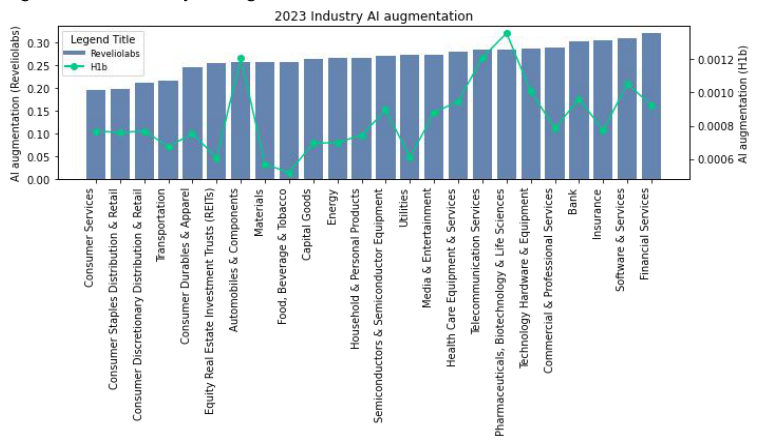

NOTE: figure/graphic rendered as an image from the PDF; its content is not machine-readable text. Caption (if any) follows as the next block.

Electronic copy available at: https://ssrn.com/abstract=4534294

Page 21

Table 5: Ranking of Industries within the S&P 500 Based on AI Augmentation from Stock Data

[output not shown]

NOTE: table converted from PDF layout to HTML text; cell boundaries are reconstructed. See PDF if exact alignment matters.

Electronic copy available at: https://ssrn.com/abstract=4534294

Page 22

Table 6: Ranking of Industries within the S&P 500 Based on AI Augmentation from Incremental Data

| Industry | 2020 | 2021 | 2022 | 2023 |
| --- | --- | --- | --- | --- |
| Banks | 1 | 1 | 1 | 3 |
| Real EstateManagement & Development | 2 | 2 | 2 | 1 |
| Software& Services | 3 | 3 | 4 | 5 |
| Telecommunication Services | 4 | 4 | 8 | 6 |
| Pharmaceuticals Biotechnology & Life Sciences , | 5 | 7 | 3 | 2 |
| Insurance | 6 | 10 | 12 | 12 |
| Financial Services | 7 | 6 | 7 | 8 |
| Semiconductors & SemiconductorEquipment | 8 | 8 | 6 | 7 |
| Technology Hardware & Equipment | 9 | 5 | 5 | 4 |
| Health Care Equipment& Services | 10 | 12 | 10 | 10 |
| Household &Personal Products | 11 | 13 | 13 | 13 |
| Media& Entertainment | 12 | 9 | 11 | 9 |
| Food Beverage &Tobacco , | 13 | 18 | 18 | 18 |
| CapitalGoods | 14 | 15 | 15 | 16 |
| Commercial &Professional Services | 15 | 17 | 19 | 17 |
| Utilities | 16 | 16 | 17 | 14 |
| ConsumerDurables &Apparel | 17 | 19 | 22 | 20 |
| Automobiles& Components | 18 | 11 | 14 | 24 |
| Materials | 19 | 20 | 21 | 22 |
| ConsumerStaples Distribution &Retail | 20 | 25 | 20 | 19 |
| Energy | 21 | 14 | 9 | 11 |
| ConsumerDiscretionary Distribution& Retail | 22 | 24 | 25 | 25 |
| ConsumerServices | 23 | 23 | 24 | 23 |
| EquityReal Estate InvestmentTrusts (REITs) | 24 | 21 | 23 | 21 |
| Transportation | 25 | 22 | 16 | 15 |

NOTE: table converted from PDF layout to HTML text; cell boundaries are reconstructed. See PDF if exact alignment matters.

Electronic copy available at: https://ssrn.com/abstract=4534294

Page 23

Table 7: Regression result for all S&P 500 Stocks

Figure 5: Scatter Plot of AI Augmentation and Layoff Rate Across S&P 500 Companies

[output not shown]

NOTE: table converted from PDF layout to HTML text; cell boundaries are reconstructed. See PDF if exact alignment matters.

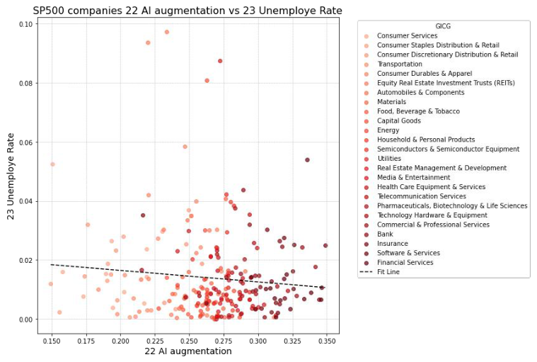

NOTE: figure/graphic rendered as an image from the PDF; its content is not machine-readable text. Caption (if any) follows as the next block.

Electronic copy available at: https://ssrn.com/abstract=4534294

Page 24

Figure 6: Regression result for all S&P 500 Industries Note: AI Augmentation is arrayed from left to right, progressing from lowest to highest.

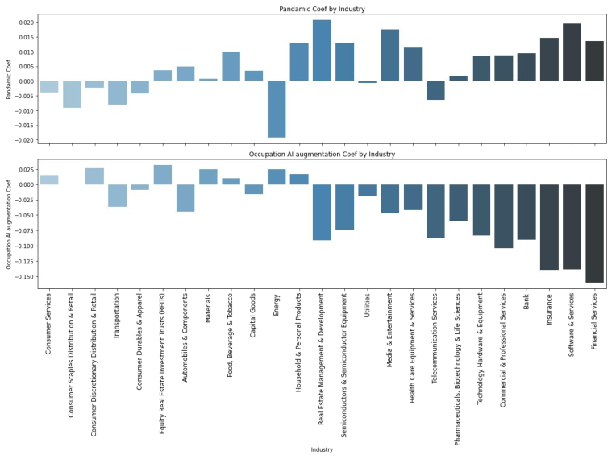

NOTE: figure/graphic rendered as an image from the PDF; its content is not machine-readable text. Caption (if any) follows as the next block.

Figure 7: Top 20 Companies with Highest Layoff Rates and their AI Augmentation Levels

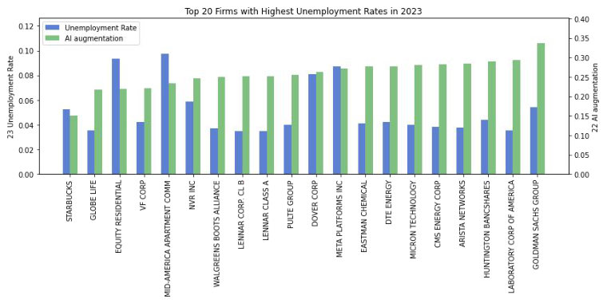

NOTE: figure/graphic rendered as an image from the PDF; its content is not machine-readable text. Caption (if any) follows as the next block.

Electronic copy available at: https://ssrn.com/abstract=4534294

Page 25

Figure 8: Top 20 Companies with Highest Layoff Number and their AI Augmentation Levels

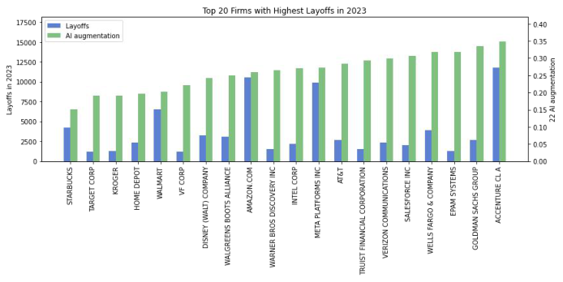

NOTE: figure/graphic rendered as an image from the PDF; its content is not machine-readable text. Caption (if any) follows as the next block.

Figure 9: Top 20 Companies with Highest Hire Rates and their AI Augmentation Levels

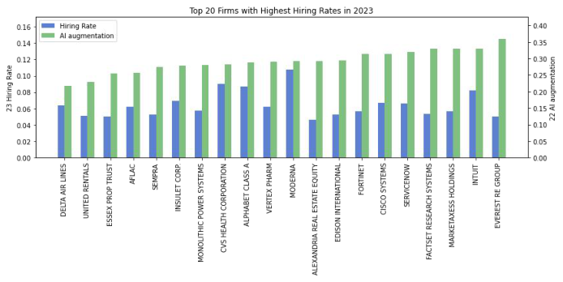

NOTE: figure/graphic rendered as an image from the PDF; its content is not machine-readable text. Caption (if any) follows as the next block.

Figure 10: Top 20 Companies with Highest Hire Number and their AI Augmentation Levels

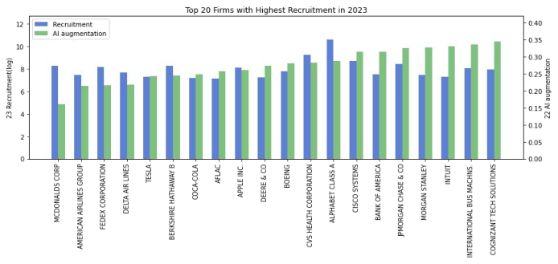

NOTE: figure/graphic rendered as an image from the PDF; its content is not machine-readable text. Caption (if any) follows as the next block.

Electronic copy available at: https://ssrn.com/abstract=4534294